# Model Only Notebook — Email Subject Spam/Ham Classifier

This notebook starts from your **clean dataframe / CSV** and trains classical ML models.

> The target is `transformer_label`, which is a pseudo-label generated earlier by a transformer model.

## 1) Install Libraries

```python
!pip install -q pandas numpy scikit-learn matplotlib seaborn joblib gradio wordcloud
```

## 2) Imports & Settings

```python
import os
import re
import json
import time
import warnings
from pathlib import Path

import numpy as np
import pandas as pd
import matplotlib.pyplot as plt
import seaborn as sns

from sklearn.model_selection import train_test_split, GridSearchCV
from sklearn.pipeline import Pipeline, FeatureUnion
from sklearn.compose import ColumnTransformer
from sklearn.preprocessing import StandardScaler, OneHotEncoder
from sklearn.impute import SimpleImputer
from sklearn.feature_extraction.text import TfidfVectorizer, CountVectorizer

from sklearn.linear_model import LogisticRegression
from sklearn.svm import LinearSVC
from sklearn.neighbors import KNeighborsClassifier
from sklearn.tree import DecisionTreeClassifier
from sklearn.ensemble import RandomForestClassifier, AdaBoostClassifier

from sklearn.metrics import (
    accuracy_score,
    precision_score,
    recall_score,
    f1_score,
    roc_auc_score,
    classification_report,
    confusion_matrix,
    ConfusionMatrixDisplay,
)

import joblib

warnings.filterwarnings("ignore")
sns.set_theme(style="whitegrid")

seed = 42
np.random.seed(seed)

OUTPUT_DIR = Path("outputs")
OUTPUT_DIR.mkdir(exist_ok=True)

# Change this path only
csv_path = "/content/clean_data.csv"

# Your important columns
subject = "subject_clean"
target = "transformer_label"

pos_class = "spam"
neg_class = "ham"
labels_ = [neg_class, pos_class]
```

```python
from google.colab import drive
drive.mount('/content/drive')
```

## 3) Load Clean CSV File

```python
csv_path = "/content/drive/MyDrive/spam_project/data_set_our_cleaning/clean_emails_final.csv"
print("CSV path:", csv_path)
df = pd.read_csv(csv_path)

print("Shape:", df.shape)
print("Columns:")
print(df.columns.tolist())

display(df.head())
```

```
CSV path: /content/drive/MyDrive/spam_project/data_set_our_cleaning/clean_emails_final.csv
Shape: (111835, 8)
Columns:
['subject', 'subject_char_len_before', 'subject_word_count_before', 'subject_clean', 'subject_char_len_after', 'subject_word_count_after', 'transformer_label', 'transformer_confidence']
```

|  | subject | subject_char_len_before | subject_word_count_before | subject_clean | subject_char_len_after | subject_word_count_after | transformer_label | transformer_confidence |
| --- | --- | --- | --- | --- | --- | --- | --- | --- |
| 0 | Re: test | 8 | 2 | test | 4 | 1 | ham | 0.997542 |
| 1 | Re: Hello | 9 | 2 | hello | 5 | 1 | ham | 0.998427 |
| 2 | Re: PRC review - phone calls | 28 | 6 | prc review phone call | 21 | 4 | ham | 0.844665 |
| 3 | FW: fixed forward or other Collar floor gas pr... | 55 | 10 | fw fixed forward collar floor gas price term | 44 | 8 | ham | 0.936518 |
| 4 | Consolidated positions: Issues & To Do list | 43 | 7 | consolidated position issue list | 32 | 4 | ham | 0.702683 |

```python
print("Data types:")
display(df.dtypes.to_frame("dtype"))

print("Missing values:")
display(df.isna().sum().to_frame("missing"))

print("Duplicate rows:", df.duplicated().sum())
```

```
Data types:
```

|  | dtype |
| --- | --- |
| subject | object |
| subject_char_len_before | int64 |
| subject_word_count_before | int64 |
| subject_clean | object |
| subject_char_len_after | int64 |
| subject_word_count_after | int64 |
| transformer_label | object |
| transformer_confidence | float64 |

```
Missing values:
```

|  | missing |
| --- | --- |
| subject | 0 |
| subject_char_len_before | 0 |
| subject_word_count_before | 0 |
| subject_clean | 0 |
| subject_char_len_after | 0 |
| subject_word_count_after | 0 |
| transformer_label | 0 |
| transformer_confidence | 0 |

```
Duplicate rows: 0
```

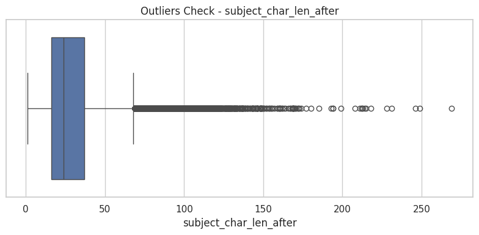

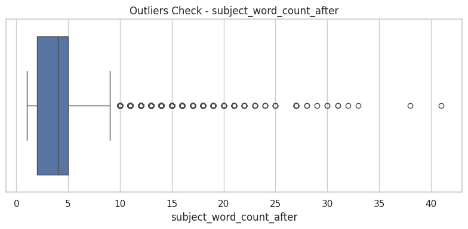

```python
import matplotlib.pyplot as plt
import seaborn as sns

numeric_quality_cols = [
    "subject_char_len_after",
    "subject_word_count_after"
]

for col in numeric_quality_cols:
    plt.figure(figsize=(8, 4))
    sns.boxplot(x=df[col])
    plt.title(f"Outliers Check - {col}")
    plt.xlabel(col)
    plt.tight_layout()
    plt.show()
```

```python
skewness_df = pd.DataFrame({
    "feature": numeric_quality_cols,
    "skewness": [df[col].skew() for col in numeric_quality_cols]
})

display(skewness_df)
```

|  | feature | skewness |
| --- | --- | --- |
| 0 | subject_char_len_after | 1.844477 |
| 1 | subject_word_count_after | 1.876389 |

```python
# Handle outliers using capping instead of deleting rows
# This keeps all samples but limits extreme length values

cap_cols = [
    "subject_char_len_after",
    "subject_word_count_after"
]

for col in cap_cols:
    cap_value = df[col].quantile(0.99)
    df[col + "_capped"] = df[col].clip(upper=cap_value)

    print(f"{col} capped at 99th percentile:", cap_value)
```

```
subject_char_len_after capped at 99th percentile: 92.0
subject_word_count_after capped at 99th percentile: 12.0
```

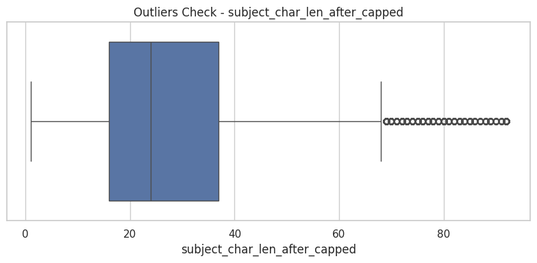

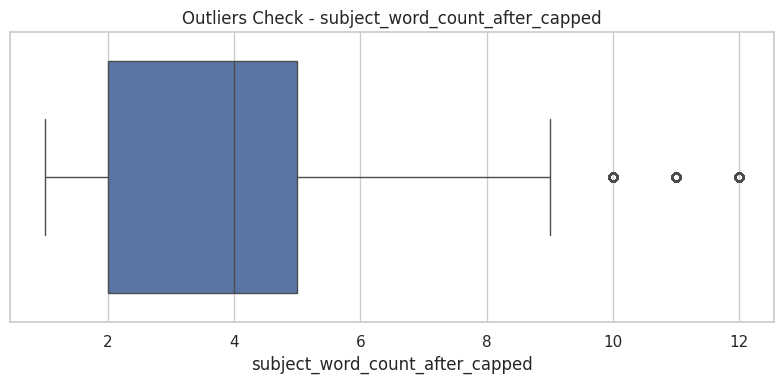

```python
import matplotlib.pyplot as plt
import seaborn as sns

numeric_quality_cols = [
    "subject_char_len_after_capped",
    "subject_word_count_after_capped"
]

for col in numeric_quality_cols:
    plt.figure(figsize=(8, 4))
    sns.boxplot(x=df[col])
    plt.title(f"Outliers Check - {col}")
    plt.xlabel(col)
    plt.tight_layout()
    plt.show()
```

```python
capped_cols = [
    "subject_char_len_after_capped",
    "subject_word_count_after_capped"
]

outlier_summary = []

for col in capped_cols:
    Q1 = df[col].quantile(0.25)
    Q3 = df[col].quantile(0.75)
    IQR = Q3 - Q1

    lower_bound = max(0, Q1 - 1.5 * IQR)
    upper_bound = Q3 + 1.5 * IQR

    upper_outliers = df[df[col] > upper_bound]

    outlier_summary.append({
        "feature": col,
        "lower_bound": lower_bound,
        "upper_bound": upper_bound,
        "upper_outlier_count": len(upper_outliers),
        "upper_outlier_percent": round(len(upper_outliers) / len(df) * 100, 2)
    })

outlier_summary_df = pd.DataFrame(outlier_summary)
display(outlier_summary_df)
```

|  | feature | lower_bound | upper_bound | upper_outlier_count | upper_outlier_percent |
| --- | --- | --- | --- | --- | --- |
| 0 | subject_char_len_after_capped | 0 | 68.5 | 4224 | 3.78 |
| 1 | subject_word_count_after_capped | 0 | 9.5 | 3860 | 3.45 |

```python
# # Remove remaining upper outliers after capping

# outlier_cols = [
#     "subject_char_len_after_capped",
#     "subject_word_count_after_capped"
# ]

# before_rows = len(df)

# keep_mask = pd.Series(True, index=df.index)

# outlier_summary = []

# for col in outlier_cols:
#     Q1 = df[col].quantile(0.25)
#     Q3 = df[col].quantile(0.75)
#     IQR = Q3 - Q1

#     upper_bound = Q3 + 1.5 * IQR

#     outlier_mask = df[col] > upper_bound
#     outlier_count = outlier_mask.sum()

#     outlier_summary.append({
#         "feature": col,
#         "upper_bound": upper_bound,
#         "outlier_count": outlier_count,
#         "outlier_percent": round(outlier_count / len(df) * 100, 2)
#     })

#     keep_mask = keep_mask & (~outlier_mask)

# outlier_summary_df = pd.DataFrame(outlier_summary)
# display(outlier_summary_df)

# rows_to_remove = (~keep_mask).sum()

# print("Rows before removing outliers:", before_rows)
# print("Rows to remove:", rows_to_remove)
# print("Rows to remove %:", round(rows_to_remove / before_rows * 100, 2), "%")

# df = df[keep_mask].copy().reset_index(drop=True)

# after_rows = len(df)

# print("Rows after removing outliers:", after_rows)
# print("Removed rows:", before_rows - after_rows)
# print("Removed percentage:", round((before_rows - after_rows) / before_rows * 100, 2), "%")
```

## 4) Extract Important Features

We do **not** use `body`, `file`, `message_id`, or `transformer_confidence` because they are either not part of the subject classifier or may cause leakage/bias.

```python
# Check required columns
required_columns = [subject, target]

numeric_cols = [
    "subject_char_len_after_capped",
    "subject_word_count_after_capped"
]

use_cols = [subject, target] + numeric_cols
data = df[use_cols].copy()
data = data.rename(columns={subject: "text", target: "label"})

print("Selected numeric features:", numeric_cols)
print("Before filtering:", data.shape)
display(data.head())
```

```
Selected numeric features: ['subject_char_len_after_capped', 'subject_word_count_after_capped']
Before filtering: (111835, 4)
```

|  | text | label | subject_char_len_after_capped | subject_word_count_after_capped |
| --- | --- | --- | --- | --- |
| 0 | test | ham | 4 | 1 |
| 1 | hello | ham | 5 | 1 |
| 2 | prc review phone call | ham | 21 | 4 |
| 3 | fw fixed forward collar floor gas price term | ham | 44 | 8 |
| 4 | consolidated position issue list | ham | 32 | 4 |

## 5) Clean Modeling Data

```python
# Drop missing text/label rows
data = data.dropna(subset=["text", "label"])

# Normalize text and label
data["text"] = data["text"].astype(str).str.strip()
data["label"] = data["label"].astype(str).str.lower().str.strip()

# Remove empty text
data = data[data["text"] != ""]

# Keep only ham/spam rows
data = data[data["label"].isin(labels_)].copy()

print("After basic filtering:", data.shape)
print(data["label"].value_counts())

display(data.head())
```

```
After basic filtering: (111835, 4)
label
ham     99040
spam    12795
Name: count, dtype: int64
```

|  | text | label | subject_char_len_after_capped | subject_word_count_after_capped |
| --- | --- | --- | --- | --- |
| 0 | test | ham | 4 | 1 |
| 1 | hello | ham | 5 | 1 |
| 2 | prc review phone call | ham | 21 | 4 |
| 3 | fw fixed forward collar floor gas price term | ham | 44 | 8 |
| 4 | consolidated position issue list | ham | 32 | 4 |

```python
print("Before removing duplicates")
print("Rows:", len(data))
print("Unique texts:", data["text"].nunique())
print("Duplicate text rows:", data.duplicated(subset=["text"]).sum())
print("Duplicate text + label rows:", data.duplicated(subset=["text", "label"]).sum())

print("\nMissing values:")
print(data.isna().sum().to_frame("missing"))
```

```
Before removing duplicates
Rows: 111835
Unique texts: 111835
Duplicate text rows: 0
Duplicate text + label rows: 0

Missing values:
                                 missing
text                                   0
label                                  0
subject_char_len_after_capped          0
subject_word_count_after_capped        0
```

```python
# Remove duplicate text rows to avoid leakage between train and test
data = data.drop_duplicates(subset=["text"]).reset_index(drop=True)

print("After removing duplicate text rows")
print("Rows:", len(data))
print("Unique texts:", data["text"].nunique())
print("Duplicate text rows:", data.duplicated(subset=["text"]).sum())
print("Duplicate text + label rows:", data.duplicated(subset=["text", "label"]).sum())
```

```
After removing duplicate text rows
Rows: 111835
Unique texts: 111835
Duplicate text rows: 0
Duplicate text + label rows: 0
```

## 6) Basic Visualizations

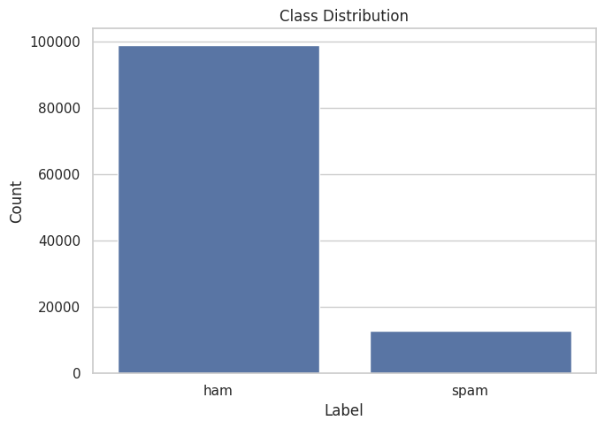

```
label
ham     99040
spam    12795
Name: count, dtype: int64
label
ham     0.88559
spam    0.11441
Name: proportion, dtype: float64
```

```python
# Label distribution
plt.figure(figsize=(7, 5))
sns.countplot(data=data, x="label", order=labels_)
plt.title("Class Distribution")
plt.xlabel("Label")
plt.ylabel("Count")
plt.tight_layout()
plt.show()

print(data["label"].value_counts())
print(data["label"].value_counts(normalize=True))
```

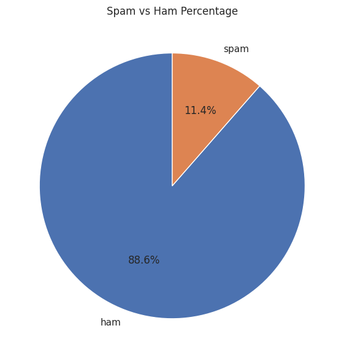

```python
# Pie chart
class_counts = data["label"].value_counts().reindex(labels_)

plt.figure(figsize=(6, 6))
plt.pie(class_counts, labels=class_counts.index, autopct="%1.1f%%", startangle=90)
plt.title("Spam vs Ham Percentage")
plt.tight_layout()
plt.show()
```

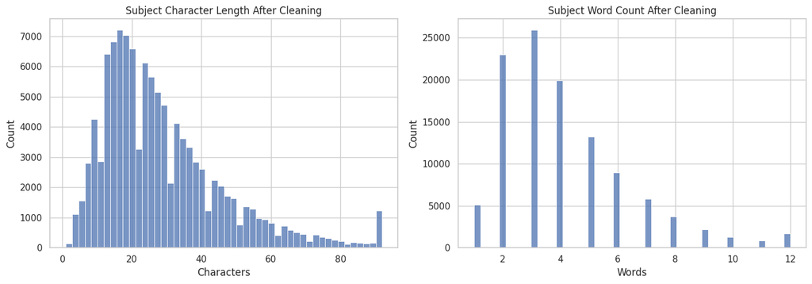

```python
# Text length distributions
fig, axes = plt.subplots(1, 2, figsize=(14, 5))

sns.histplot(df["subject_char_len_after_capped"], bins=50, ax=axes[0])
axes[0].set_title("Subject Character Length After Cleaning")
axes[0].set_xlabel("Characters")

sns.histplot(df["subject_word_count_after_capped"], bins=50, ax=axes[1])
axes[1].set_title("Subject Word Count After Cleaning")
axes[1].set_xlabel("Words")

plt.tight_layout()
plt.show()
```

## 7) Correlation Matrix

Correlation works only with numeric columns, so we use the numeric features and encoded label.

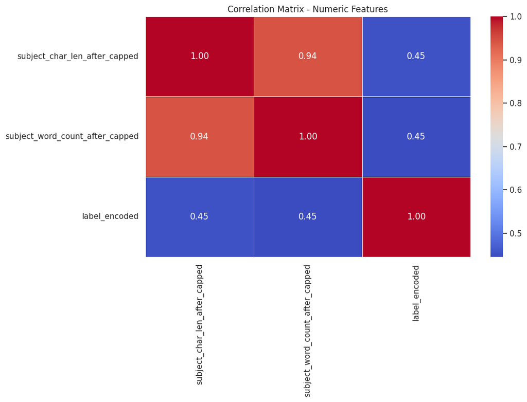

```python
corr_data = data[numeric_cols].copy()
corr_data["label_encoded"] = data["label"].map({neg_class: 0, pos_class: 1})

corr_matrix = corr_data.corr(numeric_only=True)

plt.figure(figsize=(11, 8))
sns.heatmap(
    corr_matrix,
    annot=True,
    fmt=".2f",
    cmap="coolwarm",
    linewidths=0.5,
)
plt.title("Correlation Matrix - Numeric Features")
plt.tight_layout()
plt.show()
```

## 8) Top Words / Bigrams / Trigrams

```python
def plot_top_words(texts, title, n=20, ngram_range=(1, 1)):
    vectorizer = CountVectorizer(
        stop_words="english",
        ngram_range=ngram_range,
        max_features=5000,
    )
    X_counts = vectorizer.fit_transform(texts.astype(str))
    counts = np.asarray(X_counts.sum(axis=0)).ravel()
    terms = vectorizer.get_feature_names_out()

    top_df = pd.DataFrame({"term": terms, "count": counts})
    top_df = top_df.sort_values("count", ascending=False).head(n)

    plt.figure(figsize=(10, 6))
    sns.barplot(data=top_df, y="term", x="count")
    plt.title(title)
    plt.xlabel("Count")
    plt.ylabel("")
    plt.tight_layout()
    plt.show()

    return top_df
```

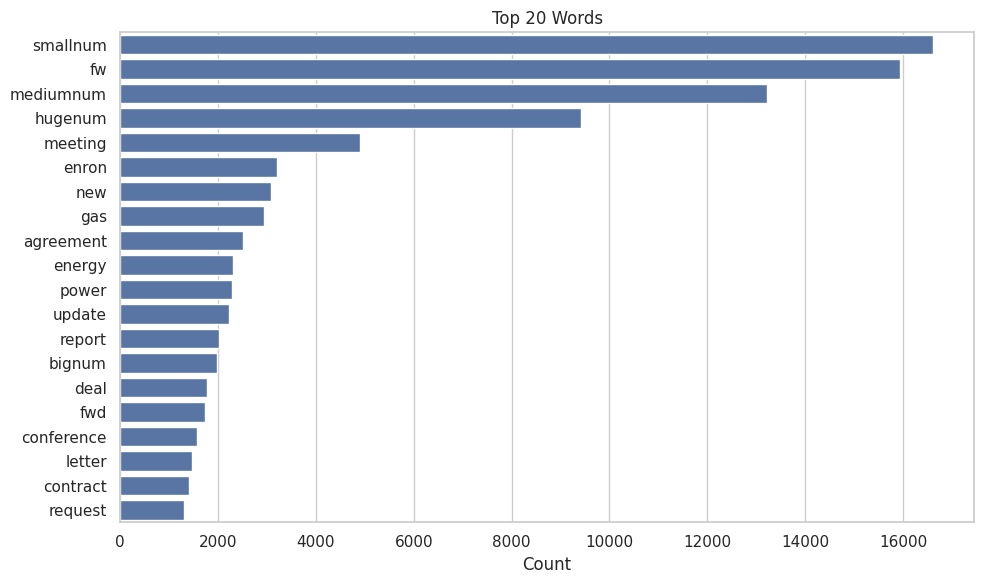

|  | term | count |
| --- | --- | --- |
| 4185 | smallnum | 16619 |
| 1854 | fw | 15932 |
| 2767 | mediumnum | 13227 |
| 2132 | hugenum | 9410 |
| 2769 | meeting | 4891 |
| 1508 | enron | 3195 |
| 3008 | new | 3073 |
| 1873 | gas | 2947 |
| 100 | agreement | 2519 |
| 1488 | energy | 2306 |
| 3470 | power | 2290 |
| 4718 | update | 2232 |
| 3796 | report | 2018 |
| 442 | bignum | 1984 |
| 1145 | deal | 1778 |
| 1855 | fwd | 1733 |
| 920 | conference | 1562 |
| 2537 | letter | 1477 |
| 971 | contract | 1415 |
| 3804 | request | 1307 |

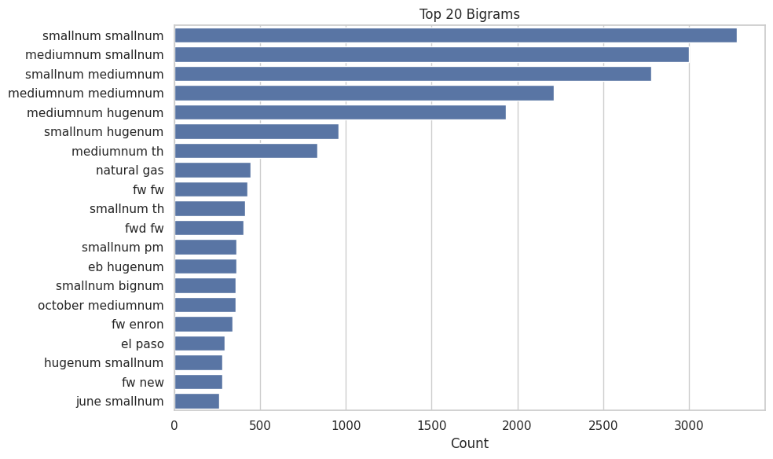

|  | term | count |
| --- | --- | --- |
| 4281 | smallnum smallnum | 3281 |
| 2877 | mediumnum smallnum | 3001 |
| 4236 | smallnum mediumnum | 2779 |
| 2845 | mediumnum mediumnum | 2211 |
| 2834 | mediumnum hugenum | 1934 |
| 4222 | smallnum hugenum | 955 |
| 2881 | mediumnum th | 833 |
| 3090 | natural gas | 444 |
| 1675 | fw fw | 427 |
| 4283 | smallnum th | 413 |
| 1960 | fwd fw | 402 |
| 4258 | smallnum pm | 363 |
| 995 | eb hugenum | 361 |
| 4171 | smallnum bignum | 356 |
| 3316 | october mediumnum | 355 |
| 1644 | fw enron | 338 |
| 1025 | el paso | 293 |
| 2323 | hugenum smallnum | 281 |
| 1782 | fw new | 277 |
| 2508 | june smallnum | 261 |

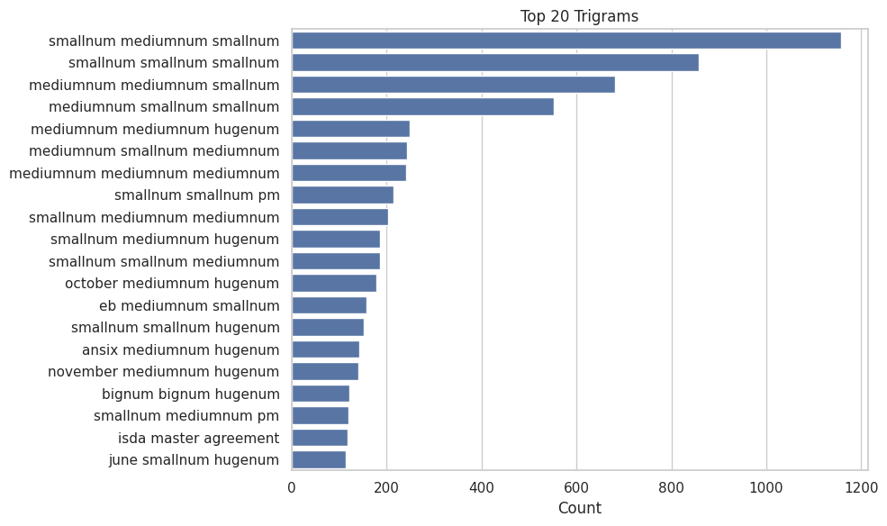

|  | term | count |
| --- | --- | --- |
| 4068 | smallnum mediumnum smallnum | 1157 |
| 4217 | smallnum smallnum smallnum | 858 |
| 2832 | mediumnum mediumnum smallnum | 681 |
| 2895 | mediumnum smallnum smallnum | 553 |
| 2822 | mediumnum mediumnum hugenum | 248 |
| 2885 | mediumnum smallnum mediumnum | 243 |
| 2824 | mediumnum mediumnum mediumnum | 241 |
| 4203 | smallnum smallnum pm | 215 |
| 4055 | smallnum mediumnum mediumnum | 203 |
| 4051 | smallnum mediumnum hugenum | 186 |
| 4193 | smallnum smallnum mediumnum | 186 |
| 3347 | october mediumnum hugenum | 179 |
| 950 | eb mediumnum smallnum | 158 |
| 4190 | smallnum smallnum hugenum | 151 |
| 147 | ansix mediumnum hugenum | 143 |
| 3308 | november mediumnum hugenum | 140 |
| 255 | bignum bignum hugenum | 122 |
| 4063 | smallnum mediumnum pm | 120 |
| 2294 | isda master agreement | 117 |
| 2413 | june smallnum hugenum | 114 |

```python
top_unigrams = plot_top_words(data["text"], "Top 20 Words", n=20, ngram_range=(1, 1))
display(top_unigrams)

top_bigrams = plot_top_words(data["text"], "Top 20 Bigrams", n=20, ngram_range=(2, 2))
display(top_bigrams)

top_trigrams = plot_top_words(data["text"], "Top 20 Trigrams", n=20, ngram_range=(3, 3))
display(top_trigrams)
```

## 9) Optional Word Cloud

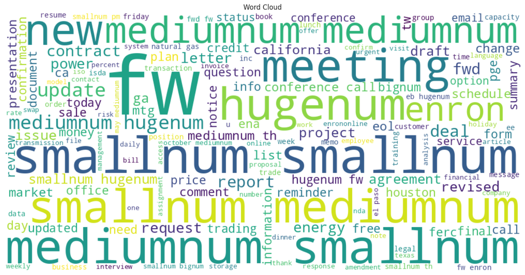

```python
try:
    from wordcloud import WordCloud

    sample_text = data["text"].astype(str).sample(
        min(len(data), 50000), random_state=seed
    )
    all_text = " ".join(sample_text)

    wc = WordCloud(
        width=1000,
        height=500,
        background_color="white",
        max_words=150,
    ).generate(all_text)

    plt.figure(figsize=(14, 7))
    plt.imshow(wc, interpolation="bilinear")
    plt.axis("off")
    plt.title("Word Cloud")
    plt.tight_layout()
    plt.show()
except Exception as e:
    print("WordCloud skipped:", e)
```

## 10) Train / Validation / Test Split

Split ratio:

- Train: 70%
- Validation: 15%
- Test: 15%

```python
X = data[["text"] + numeric_cols]
y = data["label"]

X_train, X_temp, y_train, y_temp = train_test_split(
    X,
    y,
    test_size=0.30,
    random_state=seed,
    stratify=y,
)

X_val, X_test, y_val, y_test = train_test_split(
    X_temp,
    y_temp,
    test_size=0.50,
    random_state=seed,
    stratify=y_temp,
)

print("Train:", X_train.shape, y_train.shape)
print("Validation:", X_val.shape, y_val.shape)
print("Test:", X_test.shape, y_test.shape)

print("\nSplit percentages:")
print("Train:", round(len(X_train) / len(data) * 100, 2), "%")
print("Validation:", round(len(X_val) / len(data) * 100, 2), "%")
print("Test:", round(len(X_test) / len(data) * 100, 2), "%")
```

```
Train: (78284, 3) (78284,)
Validation: (16775, 3) (16775,)
Test: (16776, 3) (16776,)

Split percentages:
Train: 70.0 %
Validation: 15.0 %
Test: 15.0 %
```

| label | train | validation | test |
| --- | --- | --- | --- |
| ham | 0.885596 | 0.885604 | 0.885551 |
| spam | 0.114404 | 0.114396 | 0.114449 |

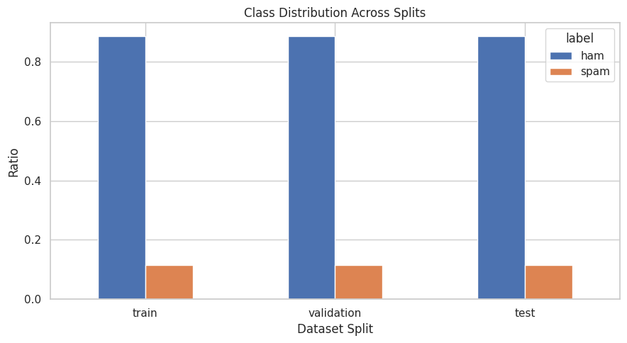

```python
split_dist = pd.DataFrame({
    "train": y_train.value_counts(normalize=True),
    "validation": y_val.value_counts(normalize=True),
    "test": y_test.value_counts(normalize=True),
}).reindex(labels_).fillna(0)

display(split_dist)

split_dist.T.plot(kind="bar", figsize=(9, 5))
plt.title("Class Distribution Across Splits")
plt.ylabel("Ratio")
plt.xlabel("Dataset Split")
plt.xticks(rotation=0)
plt.tight_layout()
plt.show()
```

## 11) Feature Engineering Pipeline

```python
def make_text_features():
    word_tfidf = TfidfVectorizer(
        analyzer="word",
        ngram_range=(1, 2),
        min_df=2,
        max_df=0.95,
        max_features=50000,
        sublinear_tf=True,
        strip_accents="unicode",
        lowercase=True,
    )

    char_tfidf = TfidfVectorizer(
        analyzer="char_wb",
        ngram_range=(3, 5),
        min_df=2,
        max_df=0.95,
        max_features=30000,
        sublinear_tf=True,
        lowercase=True,
    )

    return FeatureUnion([
        ("word_tfidf", word_tfidf),
        ("char_tfidf", char_tfidf),
    ])


def make_preprocess():
    numeric_pipe = Pipeline([
        ("imputer", SimpleImputer(strategy="median")),
        # ("scaler", StandardScaler(with_mean=False)),
    ])

    return ColumnTransformer([
        ("text", make_text_features(), "text"),
        ("num", numeric_pipe, numeric_cols),
    ])

print("Feature pipeline is ready")
```

```
Feature pipeline is ready
```

## 12) Define ML Models

```python
models = {
    "Logistic Regression": LogisticRegression(
        max_iter=3000,
        class_weight="balanced",
        random_state=seed,
        n_jobs=-1,
    ),

    "SVM": LinearSVC(
        class_weight="balanced",
        random_state=seed,
        max_iter=5000,
    ),

    "KNN": KNeighborsClassifier(
        n_neighbors=5,
        weights="distance",
        metric="cosine",
    ),

    "Decision Tree": DecisionTreeClassifier(
        max_depth=30,
        class_weight="balanced",
        random_state=seed,
    ),

    "Random Forest": RandomForestClassifier(
        n_estimators=100,
        max_depth=30,
        class_weight="balanced",
        random_state=seed,
        n_jobs=-1,
    ),

}

print("Models:")
for name in models:
    print("-", name)
```

```
Models:
- Logistic Regression
- SVM
- KNN
- Decision Tree
- Random Forest
```

## 13) Hyperparameter Grids

Small grids are used to keep training reasonable.

```python
param_grids = {
    "Logistic Regression": {
        "clf__C": [0.1, 1, 10],
    },

    "SVM": {
        "clf__C": [0.1, 1, 10],
    },

    "KNN": {
        "clf__n_neighbors": [3, 5, 7],
        "clf__weights": ["uniform", "distance"],
    },

    "Decision Tree": {
        "clf__max_depth": [10, 20, 30],
        "clf__min_samples_split": [2, 5],
    },

    "Random Forest": {
        "clf__n_estimators": [100],
        "clf__max_depth": [20, 30],
    },

    "AdaBoost": {
        "clf__n_estimators": [50, 100],
        "clf__learning_rate": [0.5, 0.8, 1.0],
    },
}
```

## 14) Helper Functions for Evaluation

```python
def get_positive_scores(model, X_values):
    """Get score for positive class. Used for ROC-AUC only."""
    classes = list(model.classes_)
    pos_index = classes.index(pos_class)

    if hasattr(model, "predict_proba"):
        scores = model.predict_proba(X_values)
        return scores[:, pos_index], "proba"

    if hasattr(model, "decision_function"):
        scores = np.asarray(model.decision_function(X_values))
        if scores.ndim == 1:
            if classes[1] == pos_class:
                return scores, "decision"
            return -scores, "decision"
        return scores[:, pos_index], "decision"

    return None, None


def safe_roc_auc(y_true, scores):
    if scores is None:
        return np.nan
    try:
        y_true_binary = (pd.Series(y_true).values == pos_class).astype(int)
        return roc_auc_score(y_true_binary, scores)
    except Exception:
        return np.nan


def evaluate_predictions(y_true, y_pred, scores=None, prefix=""):
    return {
        prefix + "accuracy": accuracy_score(y_true, y_pred),
        prefix + "precision_macro": precision_score(y_true, y_pred, average="macro", zero_division=0),
        prefix + "recall_macro": recall_score(y_true, y_pred, average="macro", zero_division=0),
        prefix + "f1_macro": f1_score(y_true, y_pred, average="macro", zero_division=0),
        prefix + "spam_precision": precision_score(y_true, y_pred, pos_label=pos_class, zero_division=0),
        prefix + "spam_recall": recall_score(y_true, y_pred, pos_label=pos_class, zero_division=0),
        prefix + "spam_f1": f1_score(y_true, y_pred, pos_label=pos_class, zero_division=0),
        prefix + "roc_auc": safe_roc_auc(y_true, scores),
    }

print("Evaluation helpers are ready")
```

```
Evaluation helpers are ready
```

## 15) Train All Models

This version uses normal `predict()` instead of threshold tuning because threshold tuning can make predictions extreme if validation scores are not well separated.

```python
results = []
trained_models = {}
score_types = {}

for model_name, model in models.items():
    print("=" * 90)
    print(f"Training: {model_name}")

    pipeline = Pipeline([
        ("features", make_preprocess()),
        ("clf", model),
    ])

    grid = GridSearchCV(
        estimator=pipeline,
        param_grid=param_grids[model_name],
        scoring="f1_macro",
        cv=3,
        n_jobs=-1,
        verbose=1,
    )

    start_train = time.time()
    grid.fit(X_train, y_train)
    train_time = time.time() - start_train

    best_pipeline = grid.best_estimator_
    trained_models[model_name] = best_pipeline

    print("Best Params:", grid.best_params_)
    print("Best CV Score:", grid.best_score_)

    # Validation prediction
    start_pred = time.time()
    val_pred = best_pipeline.predict(X_val)
    val_pred_time = time.time() - start_pred

    # Test prediction
    start_pred = time.time()
    test_pred = best_pipeline.predict(X_test)
    test_pred_time = time.time() - start_pred

    # Scores for ROC-AUC only
    val_scores, score_type = get_positive_scores(best_pipeline, X_val)
    test_scores, _ = get_positive_scores(best_pipeline, X_test)

    val_metrics = evaluate_predictions(y_val, val_pred, scores=val_scores, prefix="val_")
    test_metrics = evaluate_predictions(y_test, test_pred, scores=test_scores, prefix="test_")

    row = {
        "model": model_name,
        "best_params": grid.best_params_,
        "best_cv_score": grid.best_score_,
        "train_time_sec": train_time,
        "val_prediction_time_sec": val_pred_time,
        "test_prediction_time_sec": test_pred_time,
        "score_type": score_type,
        **val_metrics,
        **test_metrics,
    }

    results.append(row)
    score_types[model_name] = score_type

    print(f"Done: {model_name}")
    print(f"Train time: {train_time:.2f} sec")
    print("Validation prediction distribution:")
    print(pd.Series(val_pred).value_counts())
    print("Test prediction distribution:")
    print(pd.Series(test_pred).value_counts())
    print(f"Validation spam F1: {val_metrics['val_spam_f1']:.4f}")
    print(f"Test spam F1: {test_metrics['test_spam_f1']:.4f}")
    print(f"Test accuracy: {test_metrics['test_accuracy']:.4f}")
```

```
==========================================================================================
Training: Logistic Regression
Fitting 3 folds for each of 3 candidates, totalling 9 fits
Best Params: {'clf__C': 10}
Best CV Score: 0.8676867353311795
Done: Logistic Regression
Train time: 283.07 sec
Validation prediction distribution:
ham     14385
spam     2390
Name: count, dtype: int64
Test prediction distribution:
ham     14437
spam     2339
Name: count, dtype: int64
Validation spam F1: 0.7737
Test spam F1: 0.7730
Test accuracy: 0.9424
==========================================================================================
Training: SVM
Fitting 3 folds for each of 3 candidates, totalling 9 fits
Best Params: {'clf__C': 10}
Best CV Score: 0.8639158483346284
Done: SVM
Train time: 719.69 sec
Validation prediction distribution:
ham     14790
spam     1985
Name: count, dtype: int64
Test prediction distribution:
ham     14812
spam     1964
Name: count, dtype: int64
Validation spam F1: 0.7889
Test spam F1: 0.7827
Test accuracy: 0.9497
==========================================================================================
Training: KNN
Fitting 3 folds for each of 6 candidates, totalling 18 fits
Best Params: {'clf__n_neighbors': 3, 'clf__weights': 'distance'}
```

[output cut: 35 more lines]

```
Best Params: {'clf__max_depth': 30, 'clf__n_estimators': 100}
Best CV Score: 0.7880755560380241
Done: Random Forest
Train time: 178.59 sec
Validation prediction distribution:
ham     14415
spam     2360
Name: count, dtype: int64
Test prediction distribution:
ham     14432
spam     2344
Name: count, dtype: int64
Validation spam F1: 0.6207
Test spam F1: 0.6327
Test accuracy: 0.9067
```

## 16) Results Table

```python
results_df = pd.DataFrame(results)

# Sort by spam F1 first, then macro F1
results_df = results_df.sort_values(
    by=["test_spam_f1", "test_f1_macro"],
    ascending=False,
).reset_index(drop=True)

important_cols = [
    "model",
    "test_accuracy",
    "test_precision_macro",
    "test_recall_macro",
    "test_f1_macro",
    "test_spam_precision",
    "test_spam_recall",
    "test_spam_f1",
    "test_roc_auc",
    "train_time_sec",
    "test_prediction_time_sec",
    "best_params",
]

display(results_df[important_cols])

metrics_path = OUTPUT_DIR / "model_comparison.csv"
results_df.to_csv(metrics_path, index=False)
print("Saved:", metrics_path)
```

[output not shown]

```
Saved: outputs/model_comparison.csv
```

## 17) Model Comparison Visualizations

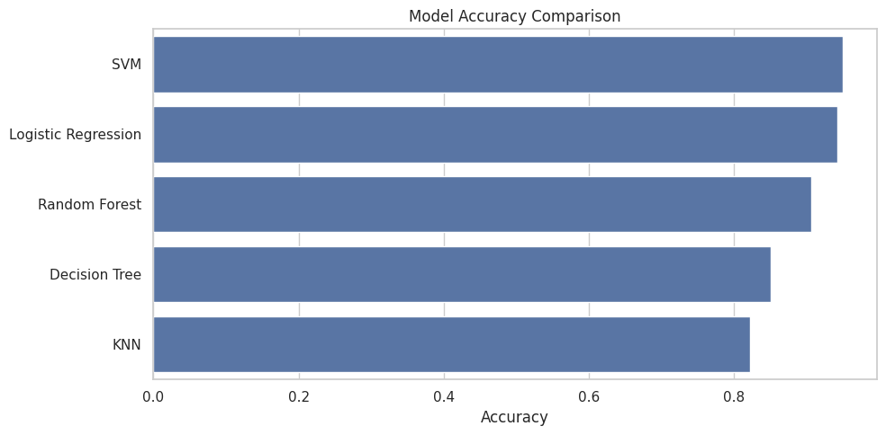

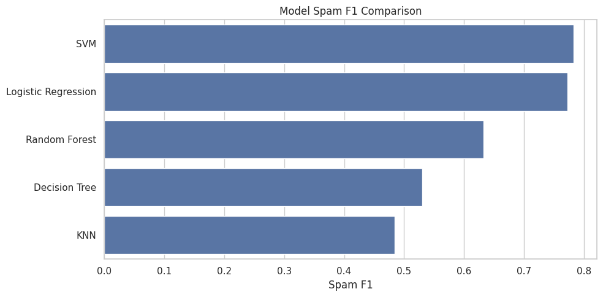

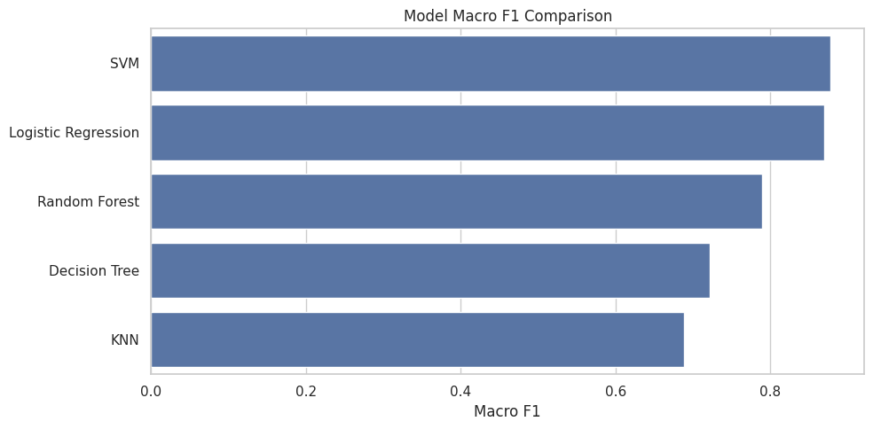

```python
plot_df = results_df.copy()

plt.figure(figsize=(10, 5))
sns.barplot(data=plot_df, x="test_accuracy", y="model")
plt.title("Model Accuracy Comparison")
plt.xlabel("Accuracy")
plt.ylabel("")
plt.tight_layout()
plt.show()

plt.figure(figsize=(10, 5))
sns.barplot(data=plot_df, x="test_spam_f1", y="model")
plt.title("Model Spam F1 Comparison")
plt.xlabel("Spam F1")
plt.ylabel("")
plt.tight_layout()
plt.show()

plt.figure(figsize=(10, 5))
sns.barplot(data=plot_df, x="test_f1_macro", y="model")
plt.title("Model Macro F1 Comparison")
plt.xlabel("Macro F1")
plt.ylabel("")
plt.tight_layout()
plt.show()
```

## 18) Best Model Evaluation

```python
best_model_name = results_df.iloc[0]["model"]
best_model = trained_models[best_model_name]

print("Best model:", best_model_name)
print("Best test spam F1:", results_df.iloc[0]["test_spam_f1"])
print("Best test macro F1:", results_df.iloc[0]["test_f1_macro"])

y_test_pred = best_model.predict(X_test)
print(classification_report(y_test, y_test_pred, labels=labels_, zero_division=0))
```

```
Best model: SVM
Best test spam F1: 0.7826982492276005
Best test macro F1: 0.8771250447971628
              precision    recall  f1-score   support

         ham       0.97      0.97      0.97     14856
        spam       0.77      0.79      0.78      1920

    accuracy                           0.95     16776
   macro avg       0.87      0.88      0.88     16776
weighted avg       0.95      0.95      0.95     16776
```

## 19) Confusion Matrix

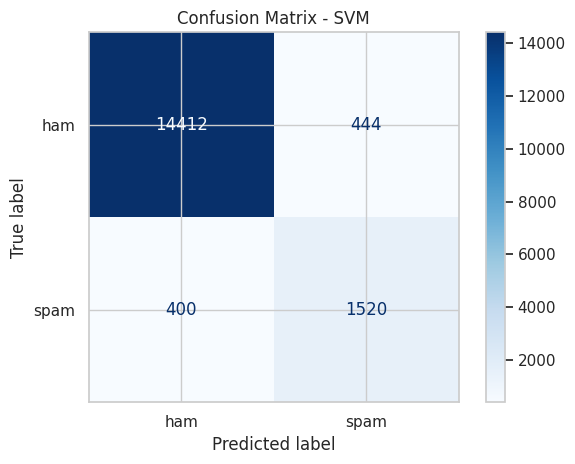

```python
cm = confusion_matrix(y_test, y_test_pred, labels=labels_)

disp = ConfusionMatrixDisplay(confusion_matrix=cm, display_labels=labels_)
disp.plot(cmap="Blues", values_format="d")
plt.title(f"Confusion Matrix - {best_model_name}")
plt.tight_layout()
plt.show()
```

## 20) Error Analysis

```python
error_df = X_test.copy()
error_df["true_label"] = y_test.values
error_df["pred_label"] = y_test_pred
error_df = error_df[error_df["true_label"] != error_df["pred_label"]]

print("Misclassified samples:", len(error_df))
display(error_df.head(20))
```

[output not shown]

[output not shown]

## 21) Save Best Model

```python
OUTPUT_DIR="/content/drive/MyDrive/spam_project/aah"
```

```python
best_model_path =  "/content/drive/MyDrive/spam_project/aah/best_model_pipeline.joblib"
metadata_path = "/content/drive/MyDrive/spam_project/aah/training_metadata.json"

joblib.dump(best_model, best_model_path)

metadata = {
    "best_model_name": best_model_name,
    "subject_column": subject,
    "target_column": target,
    "text_column_used": "text",
    "numeric_cols": numeric_cols,
    "labels": labels_,
    "positive_class": pos_class,
    "negative_class": neg_class,
}

with open(metadata_path, "w") as f:
    json.dump(metadata, f, indent=4)

print("Saved model:", best_model_path)
print("Saved metadata:", metadata_path)
```

```
Saved model: /content/drive/MyDrive/spam_project/aah/best_model_pipeline.joblib
Saved metadata: /content/drive/MyDrive/spam_project/aah/training_metadata.json
```

## 22) Prediction Function

```python
def simple_clean_text(text):
    """Simple cleaning for new input only."""
    text = str(text).lower()
    text = re.sub(r"http\S+|www\S+", " url ", text)
    text = re.sub(r"\S+@\S+", " email ", text)
    text = re.sub(r"[$€£]\s*\d+(\.\d+)?", " money ", text)
    text = re.sub(r"\d+(\.\d+)?\s*%", " percent ", text)
    text = re.sub(r"\d+", " num ", text)
    text = re.sub(r"!+", " exclamation ", text)
    text = re.sub(r"\?+", " question ", text)
    text = re.sub(r"[^a-zA-Z\s]", " ", text)
    text = re.sub(r"\s+", " ", text).strip()
    return text


def build_single_input(subject_text):
    cleaned = simple_clean_text(subject_text)

    row = {
        "text": cleaned,
        # "subject_char_len_before": len(str(subject_text)),
        # "subject_word_count_before": len(str(subject_text).split()),
        "subject_char_len_after": len(cleaned),
        "subject_word_count_after": len(cleaned.split()),
        # "has_cc": 0,
        # "has_bcc": 0,
        # "to_count": 1,
        # "cc_count": 0,
        # "bcc_count": 0,
        # "content_type": "unknown",
        # "content_transfer_encoding": "unknown",
    }

    return pd.DataFrame([row])


def predict_subject_spam(subject_text):
    X_new = build_single_input(subject_text)
    pred = best_model.predict(X_new)[0]

    score, score_type = get_positive_scores(best_model, X_new)
    score_value = None if score is None else float(score[0])

    return {
        "original_subject": subject_text,
        "cleaned_subject": X_new.loc[0, "text"],
        "prediction": pred,
        "spam_score": score_value,
        "score_type": score_type,
    }

examples = [
    "WIN $1000 NOW!!! Claim your free prize",
    "Meeting tomorrow about the project update",
    "Invoice attached for March payment",
    "Limited offer 50% discount click now",
]

for ex in examples:
    print(predict_subject_spam(ex))
```

[output not shown]

## 23) Optional Gradio App

```python
try:
    import gradio as gr

    def gradio_predict(subject_text):
        result = predict_subject_spam(subject_text)
        return (
            result["prediction"],
            result["spam_score"],
            result["score_type"],
            result["cleaned_subject"],
        )

    demo = gr.Interface(
        fn=gradio_predict,
        inputs=gr.Textbox(label="Email Subject"),
        outputs=[
            gr.Textbox(label="Prediction"),
            gr.Number(label="Spam Score"),
            gr.Textbox(label="Score Type"),
            gr.Textbox(label="Cleaned Subject"),
        ],
        title="Email Subject Spam Filter",
        description="Classifies an email subject as spam or ham using the trained classical ML model.",
    )

    # Uncomment in Colab
    # demo.launch(share=True)
except Exception as e:
    print("Gradio skipped:", e)
```

## Notes for Your Report

- The labels are pseudo-labels generated by a transformer model, not human labels.
- Evaluation measures how well classical ML models imitate the pseudo-labels.
- The main feature is `subject_clean`.
- Extra features are simple metadata/length features from the dataframe.
- The email body is not used for training.